# Programación para *Data Science*

### Ejercicio Opcional

Mediante la *degree centrality* hemos podido descubrir cuál es el personaje más importante del primer libro de *Juego de Tronos*. Sin embargo, esta saga consta de cinco volúmenes, por lo tanto, tiene sentido que la importancia de los personajes cambie a lo largo de los cinco libros.

En este ejercicio estudiaremos la evolución de los personajes mediante la red de relaciones de los cinco libros. Trabajaremos con los conjuntos de datos `book1.csv`,`book2.csv`, `book3.csv`,`book4.csv` y `book5.csv` **(que os proporcionamos junto con el enunciado de la PEC)**. EI

- ¿Cuál es el personaje más importante de cada libro?
- Muestra gráficamente cómo varía la importancia de Eddard Stark, Arya Stark, Tyrion Lannister, Jon Snow y Cersei Lannister en cada libro.

[output not shown]

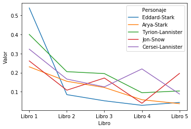

```python
# Respuesta

import numpy as np
import pandas as pd
import matplotlib.pyplot as plt
import networkx as nx
import operator

#1.
# Cargamos los datos de los ficheros de cada libro en un dataframe
book1 = pd.read_csv('data/book1.csv')
book2 = pd.read_csv('data/book2.csv')
book3 = pd.read_csv('data/book3.csv')
book4 = pd.read_csv('data/book4.csv')
book5 = pd.read_csv('data/book5.csv')

# Creamos un objeto grafo vacío
G_book1 = nx.Graph()
G_book2 = nx.Graph()
G_book3 = nx.Graph()
G_book4 = nx.Graph()
G_book5 = nx.Graph()

# Iteramos para todas las filas del dataset
for _, edge in book1.iterrows():
    G_book1.add_edge(edge['Source'], edge['Target'], weight=edge['weight'])

for _, edge in book2.iterrows():
    G_book2.add_edge(edge['Source'], edge['Target'], weight=edge['weight'])

for _, edge in book3.iterrows():
    G_book3.add_edge(edge['Source'], edge['Target'], weight=edge['weight'])

for _, edge in book4.iterrows():
    G_book4.add_edge(edge['Source'], edge['Target'], weight=edge['weight'])

for _, edge in book5.iterrows():
    G_book5.add_edge(edge['Source'], edge['Target'], weight=edge['weight'])


x1=nx.algorithms.centrality.degree_centrality(G_book1)
sorted_x1 = sorted(x1.items(), key=operator.itemgetter(1),reverse=True)

x2=nx.algorithms.centrality.degree_centrality(G_book2)
sorted_x2 = sorted(x2.items(), key=operator.itemgetter(1),reverse=True)

x3=nx.algorithms.centrality.degree_centrality(G_book3)
sorted_x3 = sorted(x3.items(), key=operator.itemgetter(1),reverse=True)

x4=nx.algorithms.centrality.degree_centrality(G_book4)
sorted_x4 = sorted(x4.items(), key=operator.itemgetter(1),reverse=True)

x5=nx.algorithms.centrality.degree_centrality(G_book5)
sorted_x5 = sorted(x5.items(), key=operator.itemgetter(1),reverse=True)

print("El personaje más importante del libro 1 es: ", sorted_x1[1][0])
print("El personaje más importante del libro 2 es: ", sorted_x2[1][0])
print("El personaje más importante del libro 3 es: ", sorted_x3[1][0])
print("El personaje más importante del libro 4 es: ", sorted_x4[1][0])
print("El personaje más importante del libro 5 es: ", sorted_x5[1][0])

#2.
#Lista las listas para luego crear un dataframe
personajes=["Eddard-Stark","Arya-Stark","Tyrion-Lannister","Jon-Snow","Cersei-Lannister"]
personajes_2=np.repeat(personajes,5)
libros=["Libro 1","Libro 2","Libro 3","Libro 4","Libro 5"]

# lista de valores para cara personaje para cada libro
a=[[x1[i],x2[i],x3[i],x4[i],x5[i]] for i in personajes]

#uso esta funciòn para convertir la lista de listas a una lista simple
flat_list = []
for sublist in a:
    for item in sublist:
        flat_list.append(item)

len(flat_list)

#creo el DataFrame
df = pd.DataFrame({
    "Personaje": personajes_2,
    "Libro": libros*5,
    "Valor": flat_list
})

#Grafico la variaciòn en la importancia de los personajes a lo largo de los libros
_=sns.lineplot(x="Libro", y="Valor", hue="Personaje", markers=True, data=df)
```

## Soluciones a los ejercicios para practicar

### Ejercicio 1

Cargad el conjunto de datos `pulitzer-circulation-data.csv` en un dataframe de Pandas. La fuente original de este conjunto de datos es el repositorio de datos de [FiveThirtyEight] (https://github.com/fivethirtyeight/data).

Cread un diagrama de dispersión que permita visualizar las muestras del conjunto de datos de pulitzer según las variables `Daily Circulation 2004` y `Daily Circulation 2013`. Incluid una recta con el ajuste lineal entre las dos variables. En cuanto a los detalles de visualización, limitad la visualización de ambos ejes en el intervalo (0, 1000000), utilice el estilo `whitegrid` de Seaborn, y dibuja los puntos y la línea en color verde.

Pista: podéis utilizar la función `jointplot` que hemos visto en el Notebook de explicación. Considerad qué tipo de gráfica, [de entre las que ofrece jointplot] (http://seaborn.pydata.org/generated/seaborn.jointplot.html), se ajusta a los requerimientos del enunciado.

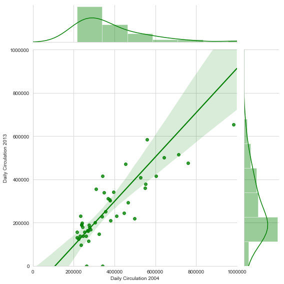

```python
# Importamos las librerías
import pandas as pd
import seaborn as sns

# Mostramos las gráficas en el notebook
%matplotlib inline

# Indicamos que queremos utilizar el estilo "whitegrid" de Seaborn
sns.set_style("whitegrid")

# Cargamos los datos del fichero pulitzer-circulation-data.csv en un dataframe
data = pd.read_csv('data/pulitzer-circulation-data.csv')

# Generamos la gráfica de tipo "reg"
g = sns.jointplot("Daily Circulation 2004", "Daily Circulation 2013", data=data,
                  xlim=[0, 1000000], ylim=[0, 1000000],
                  kind="reg",
                  color="g", height=8)
```

### Ejercicio 2

*Juego de Tronos* es una serie de televisión basada en la famosa saga *Una Canción de Fuego y Hielo* de George RR Martin. Esta serie es conocida por sus complejos escenarios políticos y bélicos, así como las numerosas muertes de personajes.

En este ejercicio trabajamos con el dataset `battles.csv` que nos da información sobre las batallas que han tenido lugar a lo largo de *Juego de Tronos*.

Cread un diagrama de puntos (*scatter*) que permita comparar el tamaño ( `attacker_size` vs`defender_size`) de los dos principales ejércitos involucrados en cada batalla. Utilizad la columna `attacker_outcome` para mostrar con diferentes colores el resultado de la batalla por el atacante.

Podéis utilizar la función [ `lmplot`] (https://seaborn.pydata.org/generated/seaborn.lmplot.html) de Seaborn para generar la gráfica. Considerad qué atributos nos permiten crear este tipo de visualización.

Viendo la gráfica, podemos afirmar que el tamaño del ejército es determinante en el *outcome* de la batalla?

Nota: utilizad el estilo `whitegrid` de Seaborn.

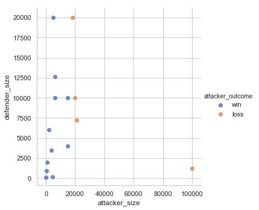

```python
# Importamos las librerías
import pandas as pd
import seaborn as sns

# Mostramos las gráficas en el notebook
%matplotlib inline

# Indicamos que queremos utilizar el estilo "whitegrid" de Seaborn
sns.set(style="whitegrid")

# Cargamos los datos del fichero got.csv en un dataframe
got_data = pd.read_csv('data/battles.csv')

# Eliminamos las muestras con valores NaN en las columnas attacker_size o defender_size
got_data = got_data.dropna(subset=["attacker_size", "defender_size"])

# Mostramos la gráfica
sns.lmplot(x="attacker_size", y="defender_size", hue="attacker_outcome", scatter=True, fit_reg=False, data=got_data)
```

**Respuesta**

Veient la gràfica anterior, no podem afirmar que la mida de l'exèrcit és determinant en l'outcome de la batalla. Com podem observar, hi ha casos on l'atacant perd la batalla tot i la superioritat numèrica de les tropes i a l'inrevés, l'atacant guanya la batalla tot i la superioritat numèrica del bàndol contrari.

### Ejercicio 3

En los reinos de Poniente, los Grandes Maestros consideran que todo el mundo debería tener acceso a una biblioteca. Desgraciadamente, después de una gran guerra la red de carreteras que comunican estos reinos ha quedado gravemente afectada. Los Grandes Maestros nos han contratado para resolver las siguientes cuestiones:

1. ¿Qué reinos han quedado sin poder acceder a una biblioteca?
2. ¿Cuál es el número mínimo de bibliotecas que se deberían construir para que todo el mundo vuelva a tener acceso a una biblioteca? (Si no podemos re-construir ninguna carretera)
3. ¿Cuál es el coste mínimo de re-construcción de carreteras a fin de que todo el mundo vuelva a tener acceso a una biblioteca? (Si no podemos construir ninguna biblioteca)
4. Viendo la respuesta de la pregunta 2 y 3, que sería lo más óptimo teniendo en cuenta que queremos minimizar los costes?

Para poder responder a estas preguntas, los Grandes Maestros nos facilitan la siguiente información:

- Disponemos de un grafo con el estado de la red de carreteras entre los reinos.
- Disponemos de un listado con las ciudades que disponen de una biblioteca.
- Una ciudad se considera que tiene acceso a una biblioteca si existe una biblioteca en la misma ciudad o si los habitantes pueden viajar por carretera hasta otra ciudad con biblioteca.
- El coste de construir una biblioteca es de 150.000 €.
- El coste de re-construir una carretera es de 80.000 €.

Nota: para resolver el ejercicio, **tenéis que generar una visualización del grafo que os permita responder a las cuatro preguntas planteadas**. Después, **recuerda responder a las cuatro preguntas!**

```python
# Datos disponibles para el ejercicio

import networkx as nx

# Lista de carreteras transitables
carreteras_ok = [(1,3), (3,4), (2, 7), (2, 8), (5, 6), (9, 10)]

# Lista de carreteras cortadas
carreteras_ko = [(1, 2), (2, 4), (2, 5), (8, 9)]

# Graf G, que representa la red de carreteras entre las ciudades
G = nx.Graph()

G.add_edges_from(carreteras_ok)
G.add_edges_from(carreteras_ko)

# Lista de ciudades con biblioteca
ciudades_con_biblioteca = [3, 6, 9]
```

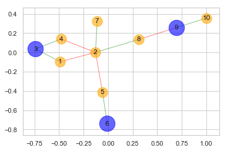

```python
%matplotlib inline

# Calculamos la posición de los nodos usando el algoritmo spring
graph_pos = nx.spring_layout(G)

# Mostramos los nodos del grafo. Mostramos con un tamaño más grande y en azul las ciudades que tienen biblioteca
nx.draw_networkx_nodes(G, graph_pos, ciudades_con_biblioteca, node_size=700, node_color='blue', alpha = 0.6)

# Mostramos con un tamaño más pequeño y en naranja los otros nodos del grafo
ciudades_sin_biblioteca = list(set(G.nodes()) - set(ciudades_con_biblioteca))
nx.draw_networkx_nodes(G, graph_pos, ciudades_sin_biblioteca, node_size=300, node_color='orange', alpha = 0.6)

# Mostramos las etiquetas del nodos, especificando el tamaño y la fuente
nx.draw_networkx_labels(G, graph_pos, font_size=12, font_family='sans-serif')

# Mostramos las aristas del grafo
# Primero, mostramos con color verde las aristas que corresponden a las carreteras que aún son transitables
nx.draw_networkx_edges(G, graph_pos, edgelist=carreteras_ok, edge_color='green', alpha=0.5)

# Mostramos con color rojo las aristas que corresponden a las carreteras cortadas
nx.draw_networkx_edges(G, graph_pos, edgelist=carreteras_ko, edge_color='red', alpha=0.5)
```

**Respuesta**

Una vez construido el grafo, podemos contestar las preguntas que nos han hecho los Grandes Maestros.

- Qué reinos han quedado sin poder acceder a una biblioteca?

Los reinos que han quedado sin acceso a una biblioteca son: `[2, 7, 8]`.

- Cuál es el número mínimo de bibliotecas que se deberían construir para que todo el mundo vuelva a tener acceso a una biblioteca? (Si no podemos re-construir ninguna carretera)

Dado que los tres reinos que han quedado sin acceso a una biblioteca están conectados entre sí (aunque quedan carreteras que los unen), podemos construir una biblioteca en cualquiera de los tres para que los ciudadanos de estos reinos puedan volver a disfrutar de una biblioteca. Por tanto, el número mínimo de bibliotecas sería **1**.

- Viendo la respuesta de la pregunta 2 y 3, que sería lo más óptimo teniendo en cuenta que queremos minimizar los costes?

En este caso, lo más óptimo sería re-construir una carretera (por ejemplo la que une los reinos 8 y 9). Esto costaría `80.000 €`, mientras que construir una biblioteca nos implica un coste de `150.000 €`.